# service

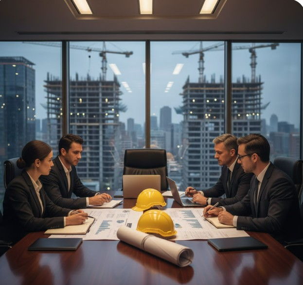

### Project management

I offer comprehensive project management services, ensuring control of scope, schedule, budget, and quality from the pre-construction stage through final delivery to clients or investors. I assist in strategic decision-making, optimizing resources, mitigating risks, and guaranteeing adherence to deadlines and technical standards. My approach combines rigorous planning, effective coordination, and continuous monitoring to achieve efficient, profitable, and well-executed projects.

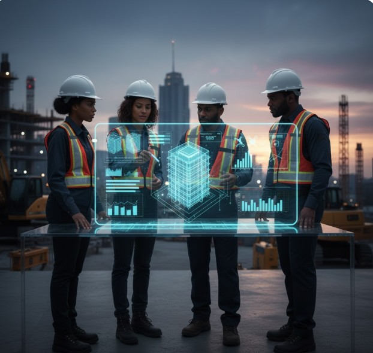

### Construction Management

I manage the entire construction process, coordinating teams, suppliers, and subcontractors to ensure orderly, safe, and compliant execution, adhering to the plans and specifications. Together with a professional team, we monitor progress, control costs, verify quality, and guarantee regulatory compliance throughout the entire construction process. My goal is to bring each project to fruition with efficiency, operational clarity, and high technical standards.

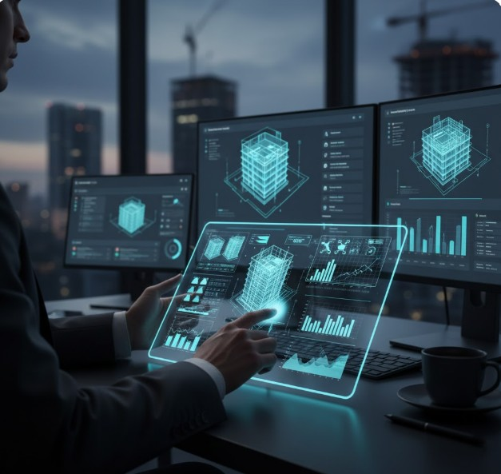

### Digital Management

I apply BIM methodology to improve the planning, coordination, and control of construction projects, integrating technical information into a collaborative digital environment. Through 3D modeling, interdisciplinary coordination, and clash detection, we optimize workflow and minimize errors during execution. I manage project models, plans, and data in an organized manner, facilitating more precise and efficient decision-making aligned with time, cost, and quality objectives.